# The Danceability of a Song Based on the Songs Characteristics

Brendan Sakihara

## Introduction

In this research project, I am interested in finding the relationship between the danceability of songs on different types of variables. I will be using songs that were released from January 1st, 2000 to December 31st, 2009 and will be observing the songs characteristics like the energy of the song, how loud the song is, the modality (mode) of the song (major or minor key), how present spoken words are (speechiness), the tempo of the song, and how lively it sounds (liveness). I am interested in this topic because I wanted to know more on why some songs are seen/known as more “danceable” than others. When I was in middle school and high school, whenever there would be some kind of event, I would hear the same type of music on the dance floor and wondered what why is it “these” songs everytime.

## Summary Statistics

**Summary Statistics**

| Statistic | Mean | St. Dev. | Median | Min | Max |
| --- | --- | --- | --- | --- | --- |
| danceability | 0.57 | 0.19 | 0.59 | 0.06 | 0.98 |
| energy | 0.67 | 0.24 | 0.71 | 0.0003 | 1.00 |
| loudness | -7.59 | 5.23 | -6.10 | -46.66 | -0.15 |
| mode | 0.65 | 0.48 | 1 | 0 | 1 |
| speechiness | 0.10 | 0.10 | 0.06 | 0.02 | 0.96 |
| liveness | 0.20 | 0.17 | 0.13 | 0.02 | 0.98 |
| tempo | 122.35 | 29.85 | 121.07 | 39.37 | 210.98 |
| ldanceability | -0.64 | 0.43 | -0.53 | -2.78 | -0.02 |
| lenergy | -0.55 | 0.74 | -0.34 | -8.29 | -0.001 |

## Main Analysis

```r
one.lm = lm(ldanceability ~ lenergy, data)
```

```r
stargazer(one.lm,type = "html",omit.table.layout = "n",omit.stat ="ser")
```

|  | *Dependent variable:* |
| --- | --- |
|  | ldanceability |
| lenergy | 0.167*** |
|  | (0.007) |
| Constant | -0.551*** |
|  | (0.006) |
| Observations | 6,398 |
| R<sup>2</sup> | 0.080 |
| Adjusted R<sup>2</sup> | 0.080 |
| F Statistic | 559.555*** (df = 1; 6396) |

This is just a regression of log(danceability) on log(energy). From this regression, the estimated equation came out to be:

$log(danceability) = -0.551 + 0.167log(energy)$

$n = 6398, R^2 = 0.08$

We see that energy is statistically significant at the 99.9 percent confidence level with a high t-value of 23.66 and a low p-value of $2e^{-16}$. Though it is statistically significant, the $R^2$ is very low at 0.08, meaning that there is still about 92% of unexplained factors. If the energy increases by 1%, the predicted danceability would increase by 0.167% The intercept is also negative which doesn’t really make sense since you can’t really go lower than 0 in danceability (not sure what you would even call that).

```r
two.lm = lm(ldanceability ~ lenergy + loudness + mode + speechiness + liveness + tempo, data)
```

```r
stargazer(one.lm, two.lm,type = "html",omit.table.layout = "n",omit.stat ="ser")
```

|  | *Dependent variable:* |  |
| --- | --- | --- |
|  | ldanceability |  |
|  | (1) | (2) |
| lenergy | 0.167*** | -0.039*** |
|  | (0.007) | (0.014) |
| loudness |  | 0.036*** |
|  |  | (0.002) |
| mode |  | -0.031*** |
|  |  | (0.010) |
| speechiness |  | 0.662*** |
|  |  | (0.052) |
| liveness |  | -0.405*** |
|  |  | (0.030) |
| tempo |  | -0.002*** |
|  |  | (0.0002) |
| Constant | -0.551*** | -0.165*** |
|  | (0.006) | (0.026) |
| Observations | 6,398 | 6,398 |
| R<sup>2</sup> | 0.080 | 0.180 |
| Adjusted R<sup>2</sup> | 0.080 | 0.179 |
| F Statistic | 559.555*** (df = 1; 6396) | 233.463*** (df = 6; 6391) |

The regression on the right is a regression of log(danceability) on log(energy), loudness, mode (mode is categorical where 1 means major key and 0 means minor key), speechiness, liveness, and tempo. The regression on the left is the regression with just my main variable log(energy) From this regression, the estimated equation came out to be :

$log(danceability) = -0.165 - 0.039log(energy) + 0.036loudness - 0.031mode + 0.662speechiness - 0.405liveness - 0.0015tempo$

$n = 6398, R^2 = 0.18$

Like in the regression with just log(energy), the intercept is still negative but closer to a positive number than the first regression. It was interesting to find that the coefficient for log(energy) became negative which doesn’t really make sense since that will mean that the more energetic the song is, the lower the danceability is. The same goes for liveness and tempo because I figured the higher those are, the higher the danceability is too. Another interesting thing is that if a song has a major key, the danceability drops. This is interesting because an easy way to describe major and minor key is that major sounds happy while minor sounds sad so seeing that the “happy” sounding songs results in a drop in danceability was surprising.

## Scatter Plot

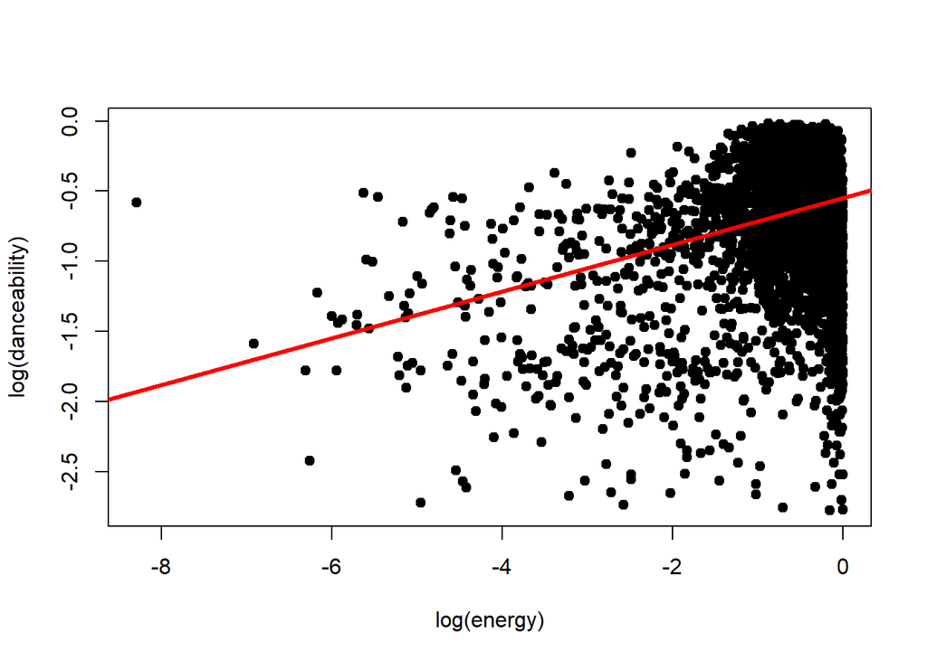

```r
plot(data$lenergy, data$ldanceability, pch=19, xlab="log(energy)", ylab="log(danceability)")
abline(lm(data$ldanceability~data$lenergy),lwd=3, col="red")
```

### Assumption 1:

The Multiple Linear Regression model assumption 1 is about the linear parameters in the population. This means that there is a linear relationship between x and y variables in the population.

There is some kind of weak linear between the x (log)energy and y (log)danceability variables in the population but it is hard to tell. It starts off looking a positive relationship but starts to clump up a lot to the right.

### Assumption 2:

The Multiple Linear Regression model assumption 2 deals with random sampling. This means that the sample data from the population is drawn randomly.

The songs in the dataset were selected randomly from the Spotify’s Web API.

### Assumption 3:

The Multiple Linear Regression model assumption 3 is no perfect collinearity. This means that there are no exact linear relationships between the x-variables.

There is no perfect collinearity. None of the variables are totally correlated with each other. Since I was able to run my regression, assumption 3 holds true.

### Assumption 4:

The Multiple Linear Regression model assumption 4 is the zero conditional mean. This means that the explanatory variable does not reveal any information about the mean of the unobserved factors.

In this regression, I think assumption 4 does not hold. I think there are just way too many unobserved factors that are closely correlated with my x-variables. Things like energy and liveness already feel closely related in my opinion so unobserved factors that are similar to that like the valence of the song (how positive the music sounds). Another variable can be the key of the piece with the mode. Minor and major key can relate to the type of key the song is in.

Ideally, when doing an experiment you want a good instrument variable in order to test this assumption.

### Assumption 5:

The Multiple Linear Regression model assumption 5 is homoskedacity. This mean that the explanatory variable does not reveal any information about the variance of the unobserved factors

```r
bptest(two.lm)
```

```
##
##  studentized Breusch-Pagan test
##
## data:  two.lm
## BP = 234.26, df = 6, p-value < 2.2e-16
```

Doing a Breusch-Pagan test, we can see that the p-value is really small at $2.2e^{-16}$, meaning we reject the null hypothesis of homoskedasticity. That means that assumption 5 does not hold and there is a heteroskedasticity problem.

We can fix this by running the regression with robust standard errors as OLS is no longer BLUE.

```r
coeftest(two.lm, vcov = vcovHC(two.lm, type="HC1"))
```

```
##
## t test of coefficients:
##
##                Estimate  Std. Error  t value  Pr(>|t|)
## (Intercept) -0.16538357  0.02802833  -5.9006 3.808e-09 ***
## lenergy     -0.03852024  0.01737178  -2.2174  0.026631 *
## loudness     0.03620152  0.00244972  14.7778 < 2.2e-16 ***
## mode        -0.03095430  0.01041804  -2.9712  0.002977 **
## speechiness  0.66181509  0.04468687  14.8101 < 2.2e-16 ***
## liveness    -0.40475454  0.03475791 -11.6450 < 2.2e-16 ***
## tempo       -0.00154380  0.00019074  -8.0939 6.862e-16 ***
## ---
## Signif. codes:  0 '***' 0.001 '**' 0.01 '*' 0.05 '.' 0.1 ' ' 1
```

This gives a more accurate estimate of the variables in the regression. The estimates for the most part stayed the same and there were some changes in the standard errors. The standard error for log(energy) slightly went up and the standard error for speechiness slightly went down. We can see that log(energy) and mode became slightly less significant (still significant).

### Assumption 6:

The Multiple Linear Regression model assumption 6 is the normality of the error terms. This means that the unobserved factors are normally distributed around the population regression function.

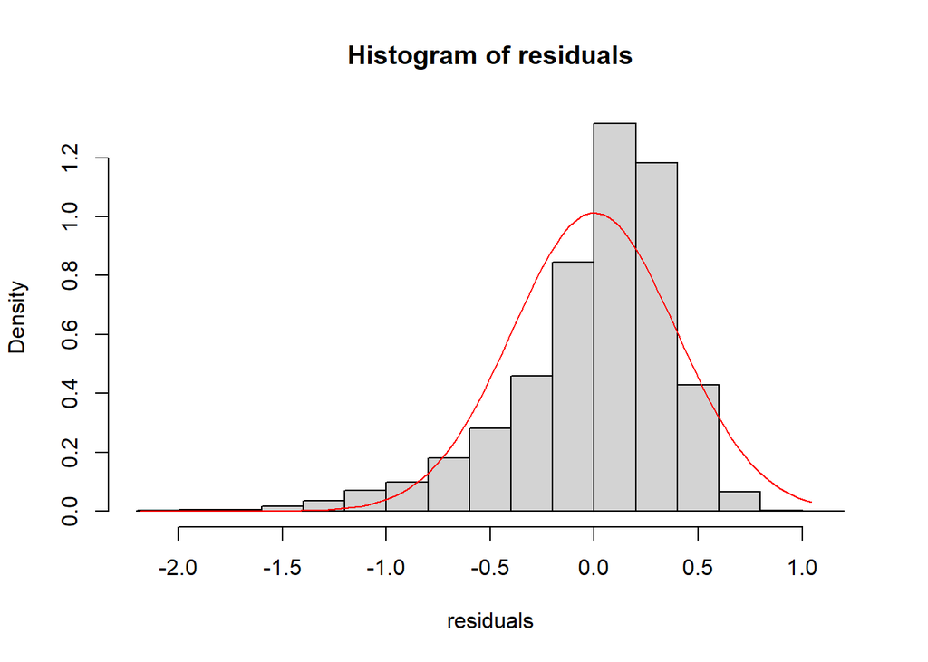

```r
residuals <- resid(two.lm)
steps <- (max(residuals)-min(residuals))/100

hist(residuals,freq=F)
lines(seq(min(residuals), max(residuals), by=steps), dnorm(seq(min(residuals), max(residuals), by=steps), 0, sd(residuals)), col="red")
```

The graph shows a weak normal distribution and is skewed towards to left. Assumption 6 does not hold.

A possible fix to this is to add or remove variables and see if residuals normally distribute.

## Conclusion

In terms of the topic and my findings, its hard to say that I learned anything from it but I learned a lot about how to do an econometrics based research paper. Things like running a regression and analyzing it seeing if all the Multiple Linear Regression assumptions hold or not and why. Given that I have determined that a lot of the assumption do not hold for my regression and a low $R^2$, there is still a lot more factors that affect the danceability of songs.

## Source

https://www.kaggle.com/theoverman/the-spotify-hit-predictor-dataset